# Yeast galactose data - code

Jackie Rao

2025-02-10

# 1 Load and pre-process data

Load the original continuous version of the 205-gene subset of the yeast galactose dataset by Ideker et al. (2001), and discretise this to a categorical dataset with 3 categories per column in line with analysis by Savage et al. (2010). Data consists expression measurements across 20 experiments (with 4 replicates each) representing perturbations of the yeast galactose utilization pathway. Each column represents 1 of 4 replicates of an experiment.

## 1.1 Load data

```r
#Load original continuous version of the data
continuousData <- read.table("https://static-content.springer.com/esm/art%3A10.1186%2Fgb-2003-4-5-r34/MediaObjects/13059_2002_544_MOESM8_ESM.txt")

#Format into data frame correctly - 205 yeast genes, 80 columns where there are 4 replicates of each of the 20 experiments
savedColnames  <- continuousData[1,]
continuousDataReduced <- continuousData[2:nrow(continuousData),]

class    <- continuousDataReduced$V3
ORF      <- continuousDataReduced$V1
GeneName <- continuousDataReduced$V2
reduced  <- continuousDataReduced[,4:ncol(continuousData)]

colnames(reduced) <- savedColnames[4:ncol(continuousData)]

reducedMatrix <- as.matrix(reduced)
reducedMatrix <- apply(reducedMatrix, 2, as.numeric)
rownames(reducedMatrix) <- ORF
savedReducedMatrix <- reducedMatrix
```

## 1.2 Discretise data

Discretise the measured value for each gene into three categories, as in Savage et al. (2010), which represents under-, over- or unchanged expression. In the analysis from this paper, the authors used the Bayesian Hierarchical Clustering (BHC) package (Savage et al., 2009) to optimise binning, where the bins “0.25, 0.50, 0.25” were found to be optimal. We replicate this pre-processing in R.

```r
# Recreate the discretised galactose dataset from the continuous version

# First take the average (mean) over the replicates:
reducedMatrix <- matrix(nrow = 205, ncol = 20)
for(j in 1:20)
{
  startIndex <- ((j-1)*4) + 1
  endIndex   <- startIndex + 3
  reducedMatrix[, j] <- rowMeans(savedReducedMatrix[,startIndex:endIndex])
}

# Now discretise using the following percentiles: 0.25, 0.50, 0.25, as in Savage et al. (2010)

galactose <- reducedMatrix
for(j in 1:205)
{

  currentData     = reducedMatrix[j,]
  lowerPercentile = quantile(currentData, 0.25);
  upperPercentile = quantile(currentData, 1-0.25);
  ##identify the discrete data values
  newData                              = seq(1,1, length = length(currentData));
  newData[currentData>lowerPercentile] = 2; ##bit of duplication here
  newData[currentData>upperPercentile] = 3;
  ##copy the current data back into thedata array
  galactose[j,] <- newData
}

rownames(galactose) <- rownames(savedReducedMatrix)
colnames(galactose) <- paste0("Exp_", seq(1,20))
```

# 2 Run VICatMix

Uncomment the below lines to run the computation - these have been commented out so the Rmd file runs quickly.

```r
#library(VICatMix)
#set.seed(205)

#library(foreach)
#library(doParallel)
#library(doRNG)
#registerDoParallel(30)

#start.time <- Sys.time()
#bigclust <- runVICatMixAvg(galactose, 10, 0.01, inits = 30, parallel = TRUE)
#end.time <- Sys.time()
#bigclust.timetaken <- end.time - start.time

#start.time2 <- Sys.time()
#littleclust <- runVICatMixAvg(galactose, 4, 0.01, inits = 30, parallel = TRUE)
#end.time2 <- Sys.time()
#littleclust.timetaken <- end.time2 - start.time2

#galactosedata_avg <- list()
#galactosedata_avg$bigtime <- bigclust.timetaken
#galactosedata_avg$littletime <- littleclust.timetaken
#galactosedata_avg$Avg10Clust <- bigclust$labels_avg
#galactosedata_avg$Avg4Clust <- littleclust$labels_avg

#save(galactosedata_avg, file="galactosedata_avg.RData")
```

# 3 Plots

## 3.1 Heatmaps

Load data for plotting - this is the output from the above computation.

```r
#Comment out the following line if VICatMix has been run by the user
load("galactosedata_avg.RData")
```

Create heatmaps with the ‘pheatmap’ package. Example below is for K = 10 simulation (Figure 3 of paper).

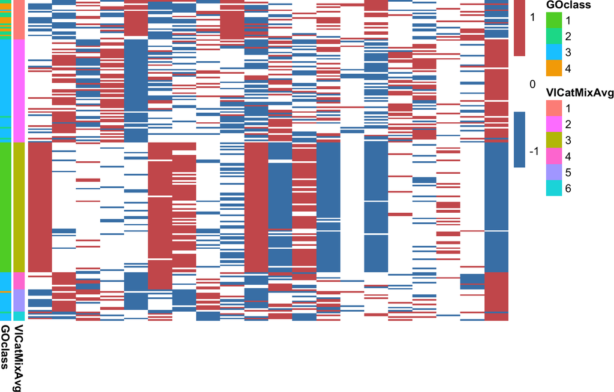

```r
realgalactoselabels <- class

currentAnnotationRow <- data.frame(
  VICatMixAvg = factor(galactosedata_avg$Avg10Clust), #Change to Avg4Clust for K = 4
  GOclass = factor(realgalactoselabels)
)
rownames(currentAnnotationRow) <- rownames(galactose)
pheatmap(galactose[order(galactosedata_avg$Avg10Clust),], #Change to Avg4Clust for K = 4
         cluster_rows = F, show_rownames = F, show_colnames = F,
         color = colorRampPalette(colors = c("steelblue", "white", "indianred"))(3),
         legend_breaks = c(1.2, 2, 2.8), legend_labels = c(-1, 0, 1),
         annotation_row = currentAnnotationRow, cluster_cols = F
)
```

```r
#Example of getting ARI

library(mclust)
adjustedRandIndex(realgalactoselabels, galactosedata_avg$Avg4Clust)
```

```
## [1] 0.9328055
```